# Variabilidad de medidas espectrales

Autor/a

Alfredo Sánchez Alberca (asalber@ceu.es)

Fecha de publicación

25 de noviembre de 2025

## 1 Preprocesamiento de los datos

Pasos de preprocesamiento de los espectros:

1. Restar el valor de la columna `Reference` de la columna `Sample` para calcular una nueva variable `Intensidad` con la intensidad real.
2. Renombramos la columna `Wave` por `Onda`“.
3. Eliminamos las columnas `Reference` y `Sample` que ya no son necesarias una vez calculada `Intensidad` y también la columna `Dark` que no es relevante para el análisis.

| Id | Medidas | Onda | Intensidad |
| --- | --- | --- | --- |
| 20250801001 | 100 | 230.218 | 0.849999999999966 |
| 20250801001 | 100 | 230.311 | 1.11099999999999 |
| 20250801001 | 100 | 230.404 | -3.35899999999998 |
| 20250801001 | 100 | 230.497 | 2.73000000000002 |
| 20250801001 | 100 | 230.591 | -2.16000000000003 |
| 20250801001 | 100 | 230.684 | -1.94 |
| 20250801001 | 100 | 230.777 | 1.851 |
| 20250801001 | 100 | 230.87 | -3.21899999999999 |
| 20250801001 | 100 | 230.964 | -5.49000000000001 |
| 20250801001 | 100 | 231.057 | -3.75 |

[output cut: 100342 more lines]

## 2 Gráficos de los espectros

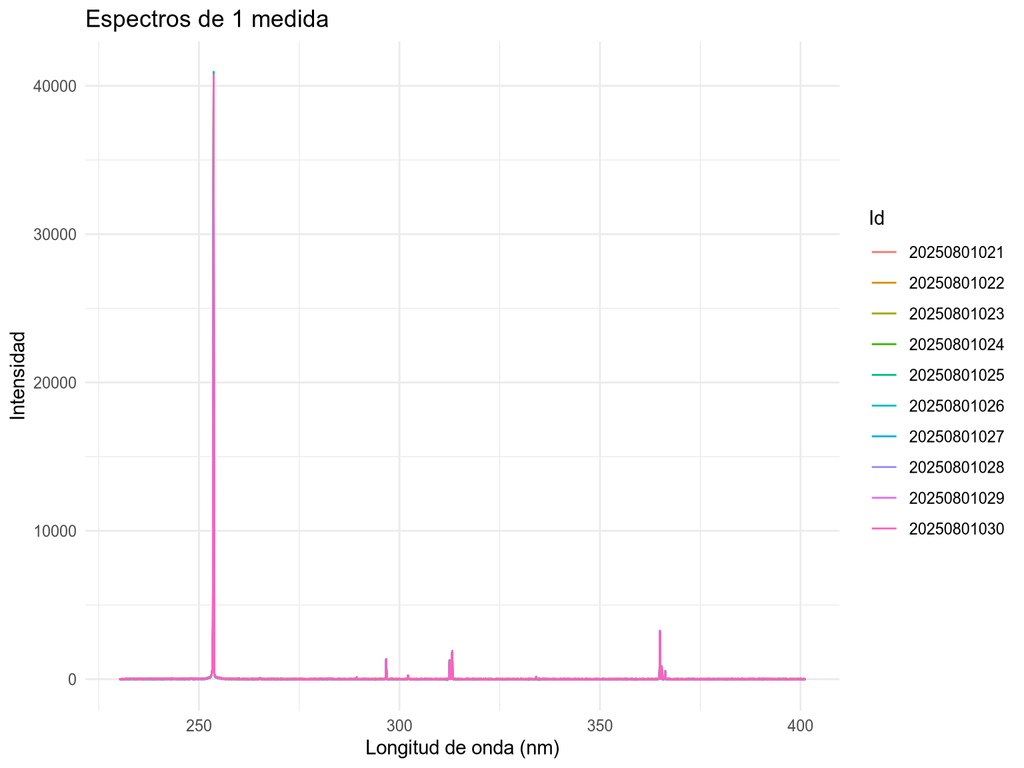

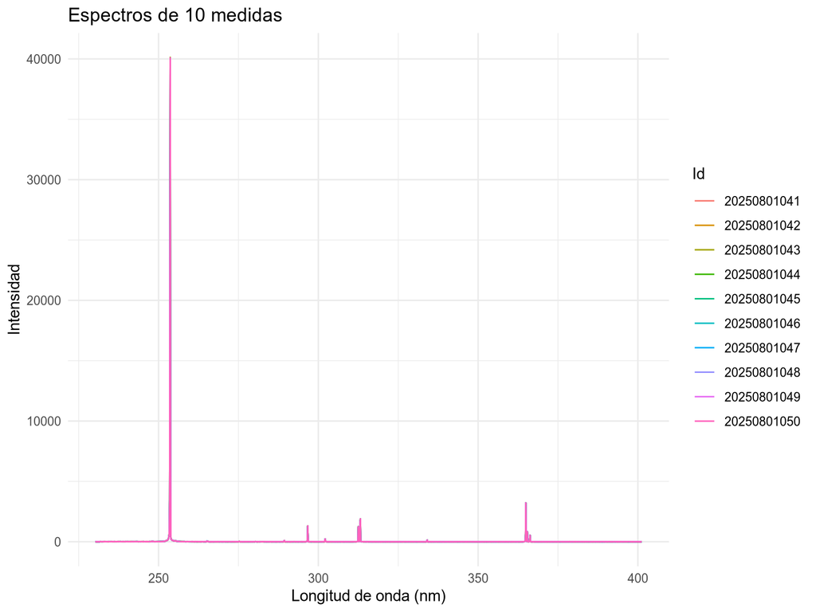

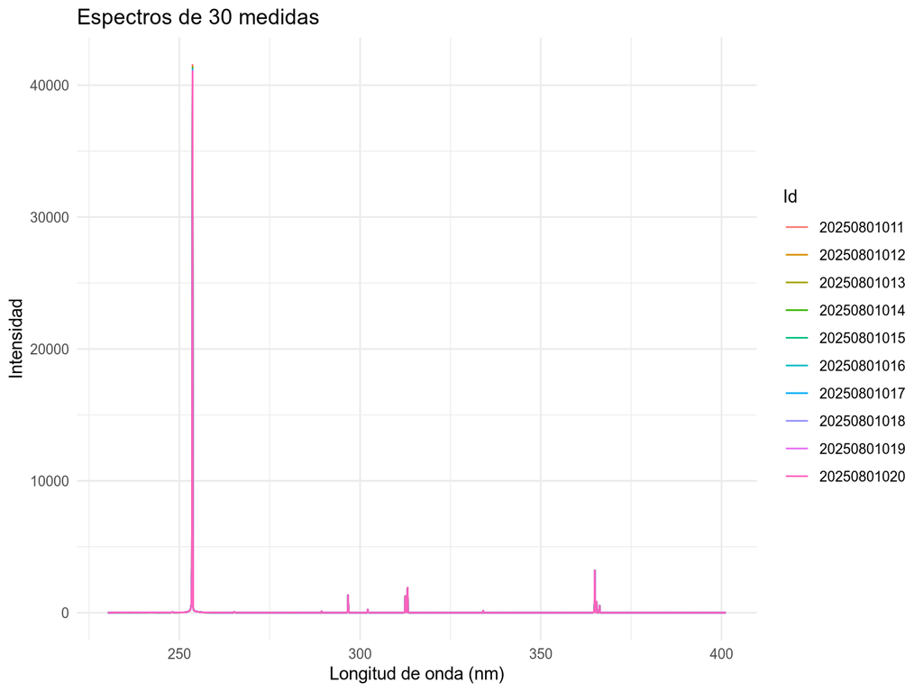

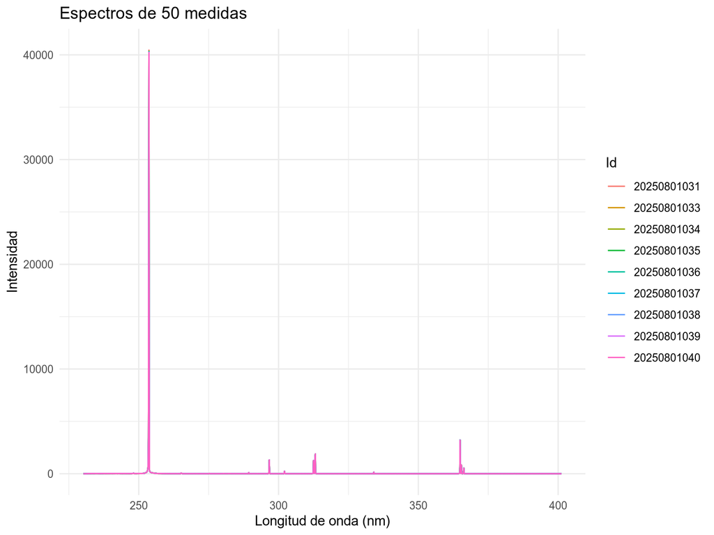

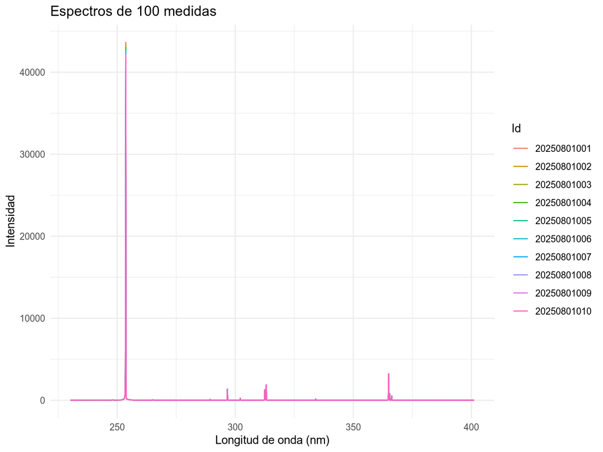

## 3 Análisis del fondo

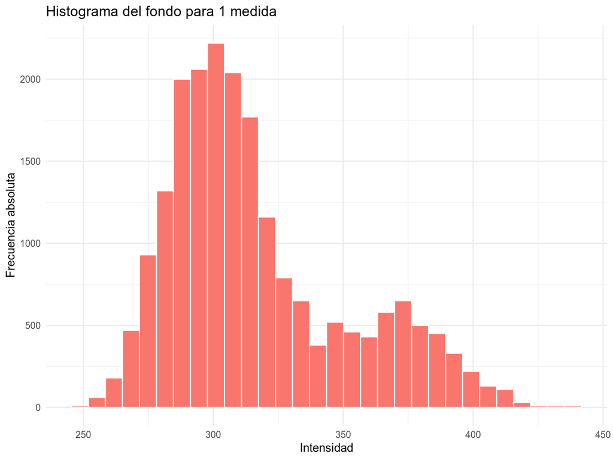

La distribución es claramente asimétrica hacia la derecha, lo que sugiere que el fondo no sigue una distribución normal.

Estadísticos del fondo para 1 medida

| Media | Desviación | CoefVariación |
| --- | --- | --- |
| 316.7081 | 34.72405 | 10.96405 |

### 3.1 Test de normalidad del fondo

Aplicamos el test de Kolmogorov-Smirnov para comprobar si el fondo sigue una distribución normal.

p-valor del test de Kolmogorov-Smirnov para normalidad del fondo (1 medida)

| p_value |
| --- |
| 0 |

El p-valor del test es menor que 0.01, lo que indica claramente que el fondo no sigue una distribución normal.

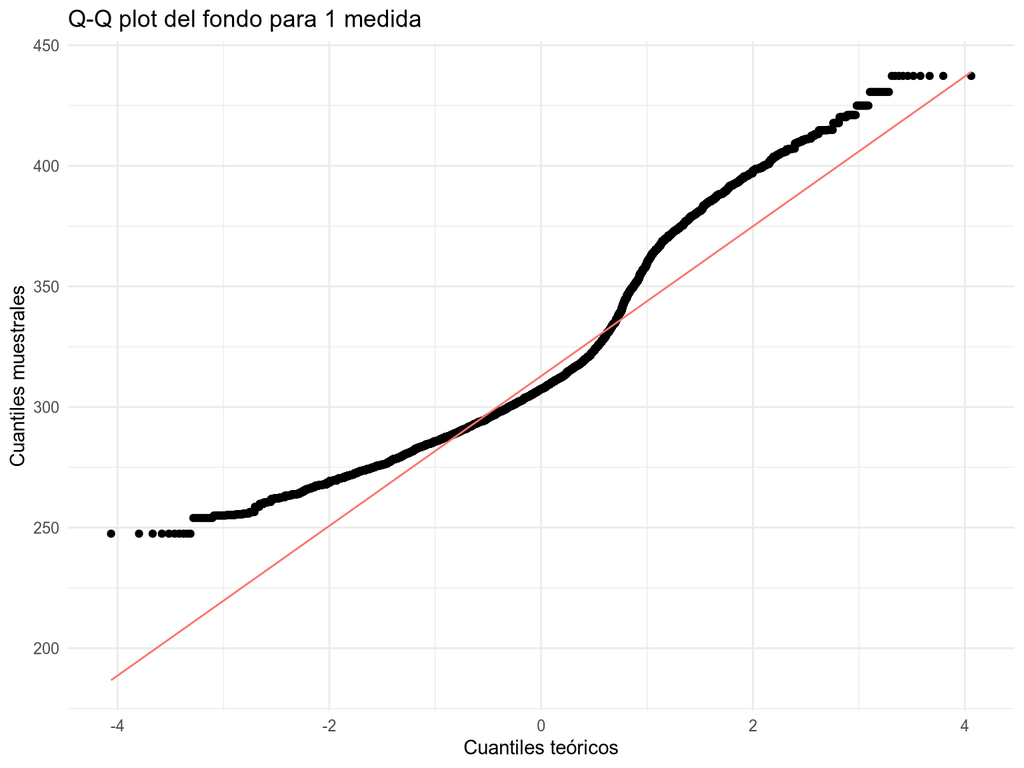

El diagrama de quantiles también indica que el fondo no sigue una distribución normal, ya que los puntos no se alinean con la línea diagonal.

### 3.2 Ajuste de modelos del fondo sobre la longitud de onda

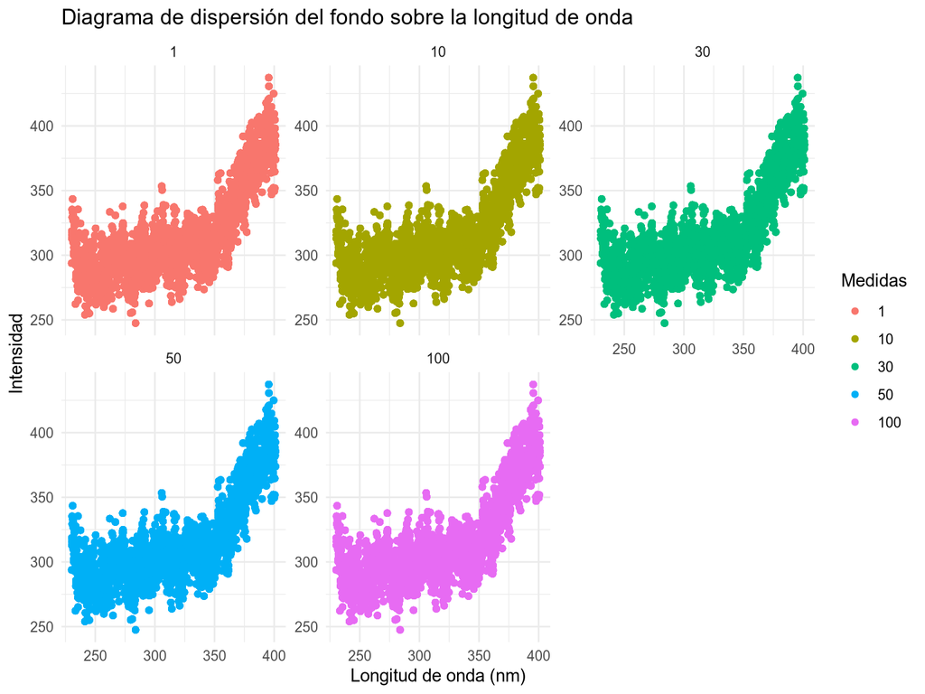

Se observa que el fondo es el mismo para cualquier número de medidas y que no es aleatorio sino que crece con la longitud de onda.

#### 3.2.1 Modelo exponencial

Ajustamos un modelo exponencial del tipo $y= ae^{bx}$ para el fondo en función de la Onda.

Coeficientes del modelo exponencial para el fondo

| term | estimate | std.error | statistic | p.value |
| --- | --- | --- | --- | --- |
| a | 177.5834270 | 0.2543614 | 698.1540 | 0 |
| b | 0.0017989 | 0.0000043 | 416.4739 | 0 |

Coeficiente de determinación del modelo exponencial para el fondo

| Coeficiente de determinación (R²) |
| --- |
| 0.6284083 |

[interactive chart not shown]

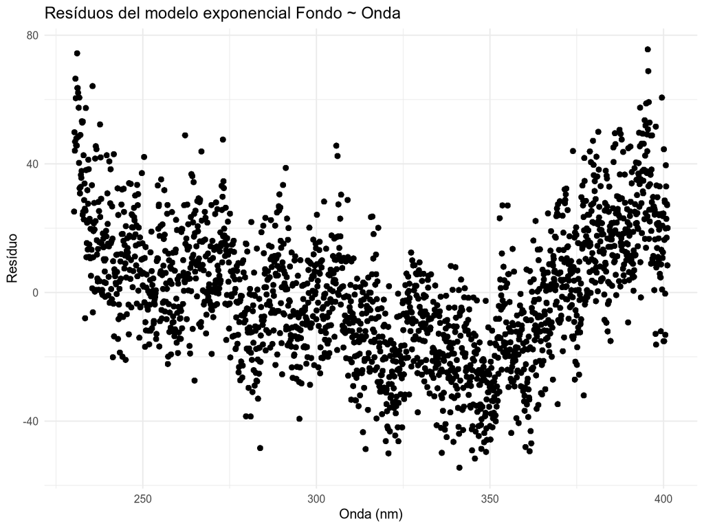

#### 3.2.2 Modelo cuadrático

Ajustamos un modelo cuadrático del tipo $y = a + b \cdot x + c \cdot x^2$ para el fondo en función de la Onda.

Coeficientes del modelo cuadrático para el fondo

| term | estimate | std.error | statistic | p.value |
| --- | --- | --- | --- | --- |
| a | 790.2077904 | 2.3556271 | 335.4554 | 0 |
| b | -3.6404792 | 0.0151047 | -241.0169 | 0 |
| c | 0.0065983 | 0.0000238 | 277.7623 | 0 |

Coeficiente de determinación del modelo cuadrático para el fondo

| Coeficiente de determinación (R²) |
| --- |
| 0.7759052 |

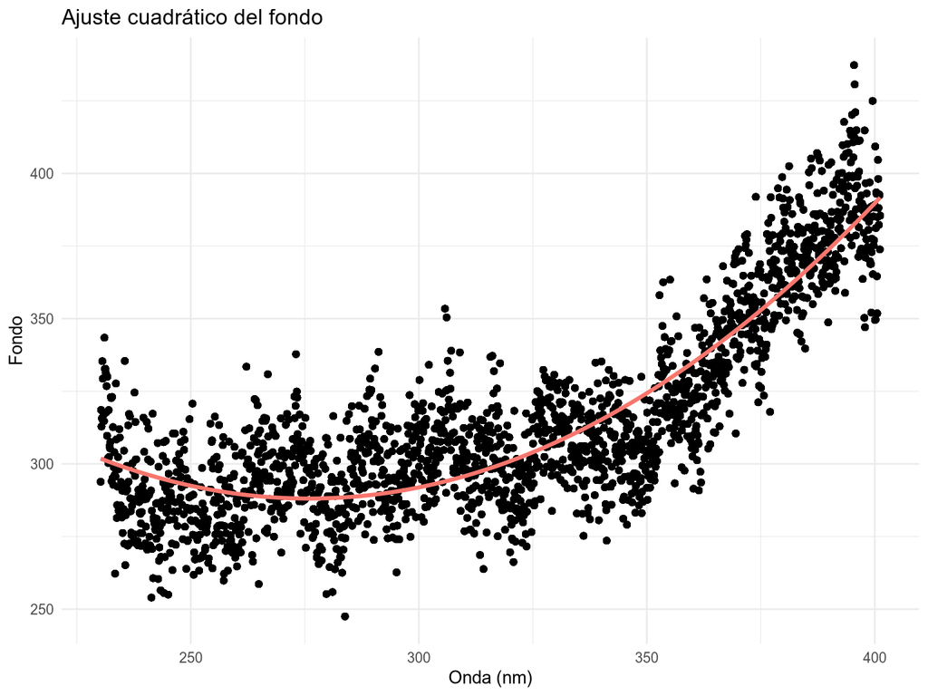

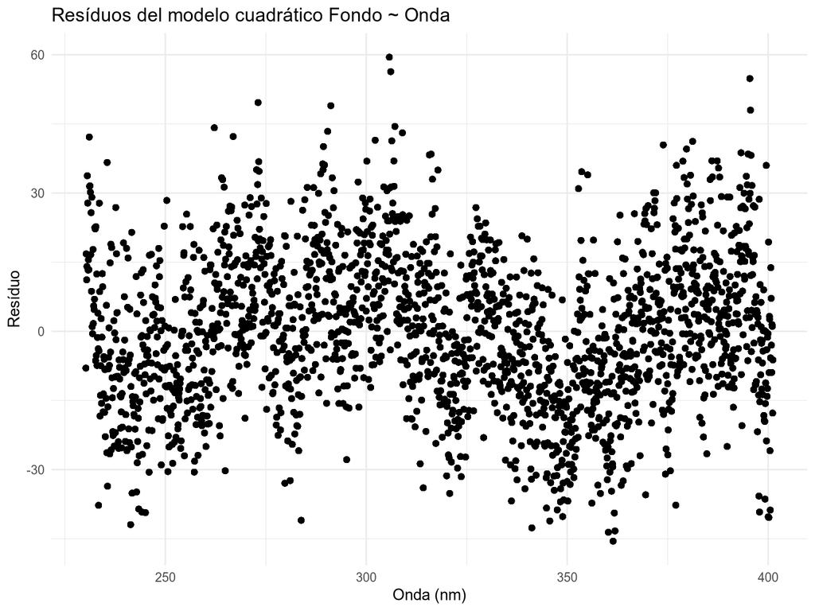

Se observa que el modelo cuadrático ajusta mejor el fondo que el modelo exponencial, ya que el coeficiente de determinación $R^2$ es mayor.

**Importante**

Habría que ver si esta dependencia de la intensidad del fondo con la Onda se produce también en la intensidad de la muestra.

### 3.3 Análisis de la normalidad del fondo en un rango reducido de longitudes de onda

Vamos a analizar la normalidad del fondo en un rango reducido de longitudes de onda, por ejemplo, entre 250 y 300 nm.

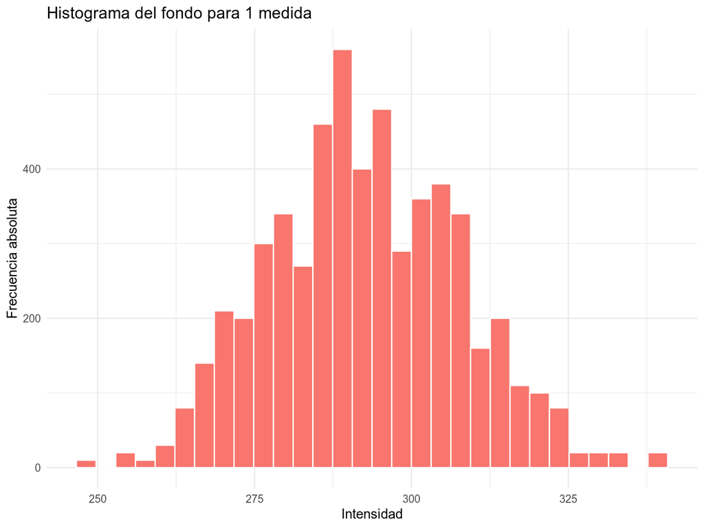

La distribución en este rango es más simétrica y presenta forma de campana, lo que sugiere que podría seguir una distribución normal.

p-valor del test de Kolmogorov-Smirnov para normalidad del fondo (1 medida, rango 250-300 nm)

| p_value |
| --- |
| 0.0002579 |

p-valor del test de D’Agostino para normalidad del fondo (1 medida, rango 250-300 nm)

| p_value |
| --- |
| 0.8243234 |

La distribución del fondo en este rango reducido de longitudes de onda sigue sin ser del todo normal, ya que el p-valor del test de Kolmogorov-Smirnov es menor que 0.05, pero el p-valor del test de D’Agostino es mayor que 0.05, lo que indica que la asimetría y la curtosis se aproximan a los valores de una distribución normal.

## 4 Análisis de la variabilidad de las medidas

Para analizar la variabilidad de las medidas espectrales, vamos a centrarnos en las longitudes de onda con intensidades significativas.

Número de longitudes de onda con intensidad significativa mayor que la media + 3 veces la desviación típica del fondo.

| n |
| --- |
| 833 |

Si consideramos como significativas aquellas intensidades mayores de la media del fondo más 3 veces la desviación típica del fondo se obtienen demasiadas longitudes de onda. Por tanto, vamos a considerar como significativas aquellas intensidades mayores que 1000.

Intensidades significativas para espectros con 1 medida

| Medidas | Onda | Fondo | 20250801021 | 20250801022 | 20250801023 | 20250801024 | 20250801025 | 20250801026 | 20250801027 | 20250801028 | 20250801029 | 20250801030 |
| --- | --- | --- | --- | --- | --- | --- | --- | --- | --- | --- | --- | --- |
| 1 | 253.469 | 276.445 | 3393.38 | 3461.405 | 3446.305 | 3393.305 | 3463.305 | 3402.255 | 3444.83 | 3563.08 | 3353.355 | 3406.955 |
| 1 | 253.561 | 278.855 | 20459.97 | 20503.995 | 20393.895 | 20398.895 | 20515.895 | 20454.844 | 20410.42 | 20141.67 | 20636.946 | 20371.545 |
| 1 | 253.652 | 280.015 | 40907.81 | 40938.837 | 40776.735 | 40928.735 | 40920.735 | 40798.684 | 40380.26 | 40394.51 | 40489.786 | 40730.383 |
| 1 | 253.743 | 280.985 | 6239.84 | 6337.865 | 6220.765 | 6339.765 | 6304.765 | 6301.715 | 6246.29 | 6334.54 | 6280.815 | 6379.415 |
| 1 | 296.674 | 297.335 | 1328.49 | 1290.515 | 1263.415 | 1314.415 | 1343.415 | 1302.365 | 1309.94 | 1346.19 | 1292.465 | 1362.065 |
| 1 | 312.485 | 292.475 | 1291.35 | 1272.375 | 1283.275 | 1268.275 | 1272.275 | 1267.225 | 1241.80 | 1212.05 | 1253.325 | 1263.925 |
| 1 | 313.080 | 286.805 | 1671.02 | 1597.045 | 1657.945 | 1601.945 | 1637.945 | 1565.895 | 1647.47 | 1635.72 | 1648.995 | 1561.595 |
| 1 | 313.165 | 305.305 | 1882.52 | 1861.545 | 1912.445 | 1849.445 | 1874.445 | 1862.395 | 1851.97 | 1825.22 | 1877.495 | 1862.095 |
| 1 | 364.939 | 319.855 | 3215.97 | 3205.995 | 3235.895 | 3128.895 | 3155.895 | 3174.845 | 3235.42 | 3239.67 | 3277.945 | 3217.545 |
| 1 | 312.570 | 279.615 | NA | 1030.235 | 1023.135 | NA | NA | NA | 1014.66 | 1010.91 | NA | 1004.785 |

Intensidades significativas para espectros con 10 medidas

| Medidas | Onda | Fondo | 20250801041 | 20250801042 | 20250801043 | 20250801044 | 20250801045 | 20250801046 | 20250801047 | 20250801048 | 20250801049 | 20250801050 |
| --- | --- | --- | --- | --- | --- | --- | --- | --- | --- | --- | --- | --- |
| 10 | 253.469 | 276.445 | 3460.50 | 3456.037 | 3459.98 | 3433.82 | 3482.198 | 3470.235 | 3470.195 | 3432.00 | 3472.615 | 3446.28 |
| 10 | 253.561 | 278.855 | 20306.19 | 20307.627 | 20225.67 | 20232.21 | 20234.288 | 20246.125 | 20192.786 | 20174.09 | 20197.305 | 20188.47 |
| 10 | 253.652 | 280.015 | 39993.63 | 40136.766 | 40045.51 | 39966.35 | 40091.829 | 40035.364 | 39930.825 | 39942.23 | 39939.145 | 40086.31 |
| 10 | 253.743 | 280.985 | 6296.76 | 6254.798 | 6303.04 | 6279.88 | 6289.057 | 6345.095 | 6342.155 | 6321.46 | 6281.575 | 6321.84 |
| 10 | 296.674 | 297.335 | 1311.51 | 1289.648 | 1287.79 | 1304.23 | 1296.207 | 1279.645 | 1297.705 | 1297.51 | 1304.825 | 1309.69 |
| 10 | 312.485 | 292.475 | 1250.57 | 1265.407 | 1248.65 | 1252.19 | 1264.567 | 1243.205 | 1251.365 | 1244.37 | 1239.185 | 1248.35 |
| 10 | 313.080 | 286.805 | 1639.64 | 1635.577 | 1629.92 | 1596.16 | 1628.737 | 1621.775 | 1641.235 | 1646.44 | 1625.655 | 1633.42 |
| 10 | 313.165 | 305.305 | 1892.34 | 1898.778 | 1883.42 | 1889.26 | 1866.538 | 1887.375 | 1871.535 | 1889.84 | 1892.555 | 1887.32 |
| 10 | 364.939 | 319.855 | 3239.99 | 3171.828 | 3220.07 | 3209.11 | 3227.587 | 3215.925 | 3187.685 | 3219.19 | 3215.705 | 3205.07 |

Intensidades significativas para espectros con 30 medidas

| Medidas | Onda | Fondo | 20250801011 | 20250801012 | 20250801013 | 20250801014 | 20250801015 | 20250801016 | 20250801017 | 20250801018 | 20250801019 | 20250801020 |
| --- | --- | --- | --- | --- | --- | --- | --- | --- | --- | --- | --- | --- |
| 30 | 253.469 | 276.445 | 3432.877 | 3430.307 | 3425.372 | 3443.396 | 3436.470 | 3431.852 | 3452.833 | 3445.402 | 3443.641 | 3433.045 |
| 30 | 253.561 | 278.855 | 20771.166 | 20756.864 | 20702.762 | 20752.819 | 20692.127 | 20667.942 | 20581.456 | 20563.625 | 20522.331 | 20484.002 |
| 30 | 253.652 | 280.015 | 41549.575 | 41393.137 | 41305.801 | 41314.758 | 41245.301 | 41232.016 | 41145.895 | 41131.032 | 41024.536 | 41057.340 |
| 30 | 253.743 | 280.985 | 6155.170 | 6165.034 | 6167.666 | 6195.689 | 6174.963 | 6235.545 | 6229.559 | 6262.295 | 6258.667 | 6286.572 |
| 30 | 296.674 | 297.335 | 1337.453 | 1309.051 | 1331.016 | 1326.839 | 1324.947 | 1322.528 | 1339.109 | 1334.912 | 1341.251 | 1323.488 |
| 30 | 312.485 | 292.475 | 1272.213 | 1254.344 | 1258.476 | 1278.566 | 1262.740 | 1253.055 | 1254.103 | 1251.238 | 1265.344 | 1252.215 |
| 30 | 313.080 | 286.805 | 1638.250 | 1656.847 | 1647.013 | 1639.269 | 1643.110 | 1633.425 | 1643.739 | 1637.108 | 1631.048 | 1631.852 |
| 30 | 313.165 | 305.305 | 1883.550 | 1903.514 | 1888.079 | 1887.036 | 1886.610 | 1893.158 | 1906.639 | 1897.742 | 1909.314 | 1897.518 |
| 30 | 364.939 | 319.855 | 3224.033 | 3210.364 | 3195.896 | 3206.119 | 3207.360 | 3212.275 | 3218.956 | 3207.292 | 3204.331 | 3203.968 |
| 30 | 312.570 | 279.615 | NA | 1005.371 | 1001.703 | NA | NA | NA | 1000.429 | 1000.832 | NA | NA |

Intensidades significativas para espectros con 50 medidas

| Medidas | Onda | Fondo | 20250801031 | 20250801033 | 20250801034 | 20250801035 | 20250801036 | 20250801037 | 20250801038 | 20250801039 | 20250801040 |
| --- | --- | --- | --- | --- | --- | --- | --- | --- | --- | --- | --- |
| 50 | 253.469 | 276.445 | 3457.183 | 3451.662 | 3433.719 | 3444.249 | 3458.775 | 3439.513 | 3463.715 | 3456.031 | 3452.143 |
| 50 | 253.561 | 278.855 | 20340.993 | 20367.952 | 20345.028 | 20344.338 | 20360.905 | 20337.022 | 20352.645 | 20349.641 | 20322.793 |
| 50 | 253.652 | 280.015 | 40457.954 | 40367.192 | 40287.708 | 40327.477 | 40293.626 | 40282.501 | 40226.786 | 40240.501 | 40209.895 |
| 50 | 253.743 | 280.985 | 6326.324 | 6348.762 | 6320.418 | 6309.268 | 6308.675 | 6306.712 | 6323.315 | 6279.210 | 6275.384 |
| 50 | 296.674 | 297.335 | 1310.634 | 1318.912 | 1303.088 | 1314.598 | 1310.825 | 1309.123 | 1313.706 | 1319.520 | 1304.833 |
| 50 | 312.485 | 292.475 | 1249.134 | 1255.252 | 1250.889 | 1255.519 | 1254.165 | 1254.523 | 1248.426 | 1257.360 | 1252.213 |
| 50 | 313.080 | 286.805 | 1628.944 | 1624.962 | 1631.778 | 1636.689 | 1636.235 | 1632.472 | 1638.236 | 1627.851 | 1642.044 |
| 50 | 313.165 | 305.305 | 1892.704 | 1893.402 | 1882.799 | 1888.168 | 1888.695 | 1890.393 | 1881.796 | 1872.810 | 1888.783 |
| 50 | 364.939 | 319.855 | 3213.293 | 3212.932 | 3216.749 | 3219.839 | 3217.525 | 3235.403 | 3203.545 | 3211.240 | 3201.474 |
| 50 | 312.570 | 279.615 | NA | NA | NA | 1000.619 | NA | NA | NA | NA | NA |

Intensidades significativas para espectros con 100 medidas

| Medidas | Onda | Fondo | 20250801001 | 20250801002 | 20250801003 | 20250801004 | 20250801005 | 20250801006 | 20250801007 | 20250801008 | 20250801009 | 20250801010 |
| --- | --- | --- | --- | --- | --- | --- | --- | --- | --- | --- | --- | --- |
| 100 | 253.469 | 276.445 | 3622.041 | 3597.952 | 3582.065 | 3567.66 | 3548.146 | 3519.057 | 3514.382 | 3475.724 | 3456.018 | 3443.311 |
| 100 | 253.561 | 278.855 | 21877.770 | 21748.213 | 21612.305 | 21490.79 | 21383.596 | 21321.487 | 21190.432 | 21054.184 | 20937.778 | 20895.471 |
| 100 | 253.652 | 280.015 | 43643.602 | 43402.883 | 43206.223 | 42991.97 | 42843.715 | 42638.528 | 42454.173 | 42200.786 | 42006.380 | 41905.219 |
| 100 | 253.743 | 280.985 | 5933.440 | 5943.162 | 5980.725 | 5981.74 | 5985.846 | 6015.737 | 6022.412 | 6052.314 | 6070.118 | 6083.091 |
| 100 | 296.674 | 297.335 | 1358.870 | 1357.582 | 1357.605 | 1354.79 | 1343.005 | 1347.147 | 1347.962 | 1346.974 | 1340.948 | 1331.151 |
| 100 | 312.485 | 292.475 | 1293.831 | 1289.973 | 1285.665 | 1284.91 | 1286.615 | 1283.767 | 1274.222 | 1269.915 | 1268.838 | 1269.831 |
| 100 | 313.080 | 286.805 | 1695.611 | 1683.112 | 1678.315 | 1676.57 | 1664.825 | 1669.497 | 1659.662 | 1657.115 | 1657.118 | 1647.281 |
| 100 | 313.165 | 305.305 | 1879.931 | 1879.673 | 1875.985 | 1887.04 | 1881.056 | 1887.557 | 1890.932 | 1883.624 | 1890.198 | 1890.541 |
| 100 | 364.939 | 319.855 | 3227.230 | 3226.492 | 3217.685 | 3221.10 | 3215.355 | 3222.447 | 3221.472 | 3209.385 | 3216.928 | 3208.111 |

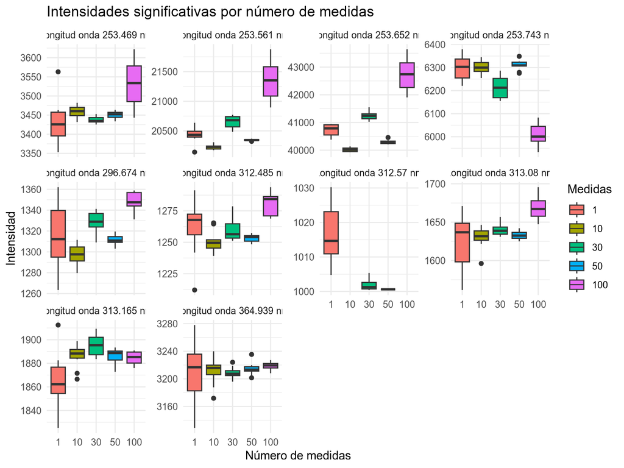

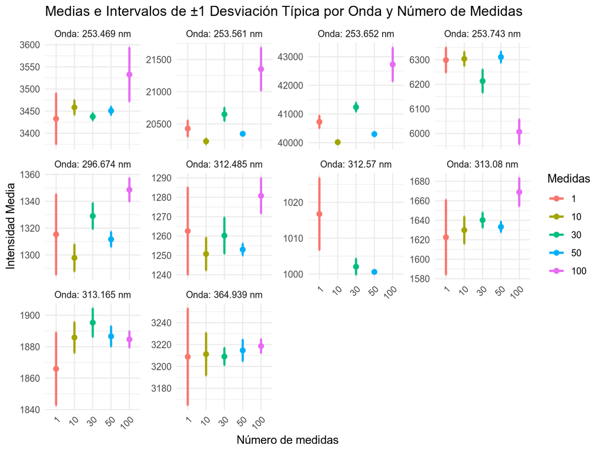

**Estadísticos de variabilidad por Onda y número de medidas**

| Onda (nm) | Medidas | Media | Desviación Típica | IC 95% Desv.Tip. | Coef.Variación(%) | IC 95% Coef.Variación(%) |
| --- | --- | --- | --- | --- | --- | --- |
| 253.469 | 1 | 3432.8175 | 57.807191798349 | [39.76, 105.53] | 1.68395761785615 | [1.16, 3.07] |
| 253.469 | 10 | 3458.386 | 16.6937090213316 | [11.48, 30.48] | 0.482702307415413 | [0.33, 0.88] |
| 253.469 | 30 | 3437.5195 | 8.4526194394926 | [5.81, 15.43] | 0.245892988810466 | [0.17, 0.45] |
| 253.469 | 50 | 3450.77666666667 | 9.76676906658484 | [6.6, 18.71] | 0.283031039386829 | [0.19, 0.54] |
| 253.469 | 100 | 3532.6356 | 61.2605978553915 | [42.14, 111.84] | 1.73413294751917 | [1.19, 3.17] |
| 253.561 | 1 | 20428.8074 | 127.535025555247 | [87.72, 232.83] | 0.624290116687122 | [0.43, 1.14] |
| 253.561 | 10 | 20230.4759 | 46.4700984539757 | [31.96, 84.84] | 0.229703436951652 | [0.16, 0.42] |
| 253.561 | 30 | 20649.5094 | 104.117728340139 | [71.62, 190.08] | 0.504214053337942 | [0.35, 0.92] |
| 253.561 | 50 | 20346.813 | 13.2450930725302 | [8.95, 25.37] | 0.0650966471875973 | [0.04, 0.12] |
| 253.561 | 100 | 21351.2026 | 336.181228393324 | [231.24, 613.74] | 1.5745306467811 | [1.08, 2.87] |

[output cut: 38 more lines]

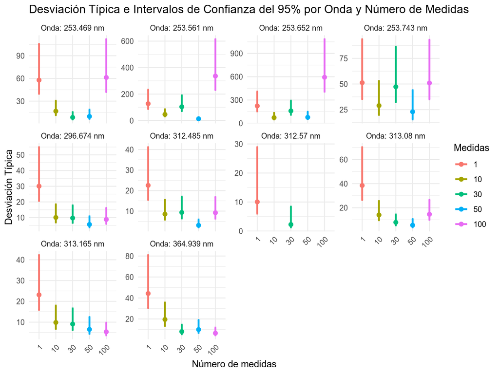